# p8-simona

2022-11-04

```r
library(tidyverse)
library(randomForest)
library(magrittr)
library(psych)
library(caret)
library(gbm)
library(xgboost)
library(data.table)
library(ggforce)
```

```r
set.seed(45)
df <- readRDS("data/train_disease.RDS")
```

1. Get an impression of the data by looking at the structure of the data and creating some descriptive statistics.

```r
summary(df)
```

```
##       Age          Gender    Total_Bilirubin  Direct_Bilirubin
##  Min.   : 4.0   Male  :377   Min.   : 0.400   Min.   : 0.100
##  1st Qu.:33.0   Female:123   1st Qu.: 0.800   1st Qu.: 0.200
##  Median :45.0                Median : 1.000   Median : 0.300
##  Mean   :44.6                Mean   : 3.237   Mean   : 1.447
##  3rd Qu.:57.0                3rd Qu.: 2.525   3rd Qu.: 1.200
##  Max.   :90.0                Max.   :75.000   Max.   :19.700
##  Alkaline_Phosphotase Alamine_Aminotransferase Aspartate_Aminotransferase
##  Min.   :  63.0       Min.   :  10.00          Min.   :  10.00
##  1st Qu.: 175.0       1st Qu.:  22.00          1st Qu.:  25.00
##  Median : 208.0       Median :  35.00          Median :  41.00
##  Mean   : 284.6       Mean   :  79.30          Mean   : 107.38
##  3rd Qu.: 292.2       3rd Qu.:  61.25          3rd Qu.:  86.25
##  Max.   :2110.0       Max.   :1680.00          Max.   :4929.00
##  Total_Protiens     Albumin      Ratio_Albumin_Globulin    Disease
##  Min.   :2.700   Min.   :0.900   Min.   :0.3000         Healthy:360
##  1st Qu.:5.800   1st Qu.:2.600   1st Qu.:0.7000         Disease:140
##  Median :6.600   Median :3.100   Median :0.9500
##  Mean   :6.489   Mean   :3.149   Mean   :0.9498
##  3rd Qu.:7.200   3rd Qu.:3.800   3rd Qu.:1.1000
##  Max.   :9.600   Max.   :5.500   Max.   :2.8000
```

```r
df = tibble(df)

df %>% group_by(Gender, Disease) %>% summarise(counts = n())
```

```
## # A tibble: 4 × 3
## # Groups:   Gender [2]
##   Gender Disease counts
##   <fct>  <fct>    <int>
## 1 Male   Healthy    280
## 2 Male   Disease     97
## 3 Female Healthy     80
## 4 Female Disease     43
```

2. To further explore the data we work with, create some interesting data visualizations that show whether there are interesting patterns in the data.

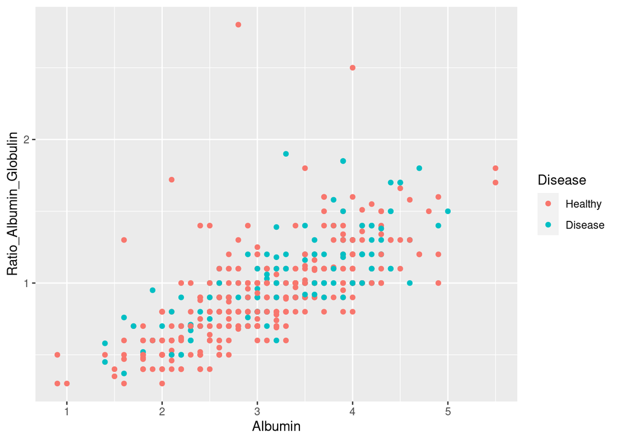

```r
df %>% ggplot(mapping = aes( x= Albumin, y = Ratio_Albumin_Globulin, color = Disease)) +
  geom_point()
```

There is a linear relationship between albumin and globun_albumin ratio, as expected. The higher values do not indicate the disease state.

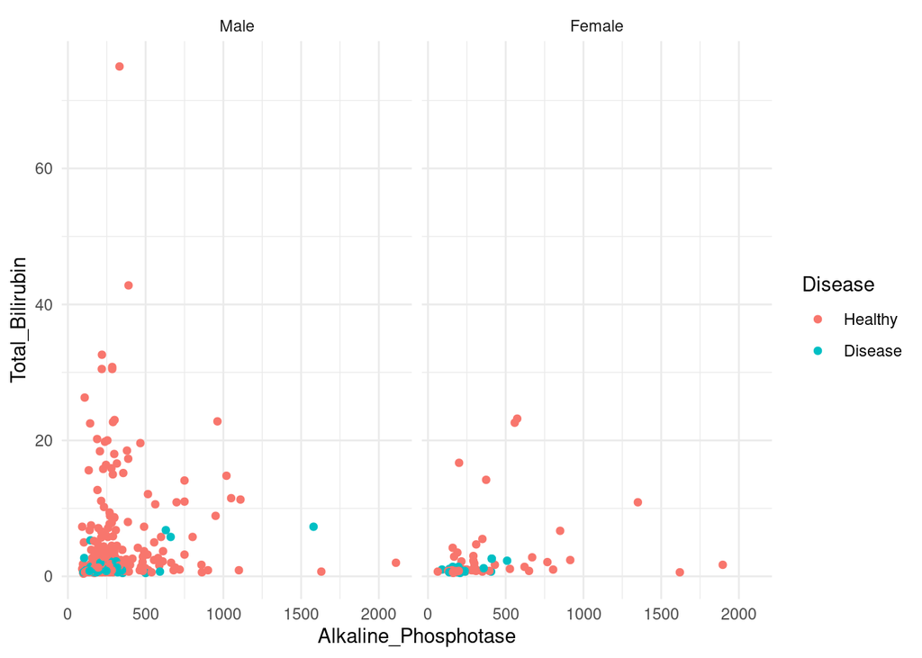

```r
df %>% ggplot(mapping = aes( x= Alkaline_Phosphotase, y = Total_Bilirubin, color = Disease)) +
  facet_wrap(~Gender) +
  geom_point() +
  theme_minimal()
```

Higher values of bilirubin or alkaline_phospatase seem to indicate an healthy state irrespective of gender.

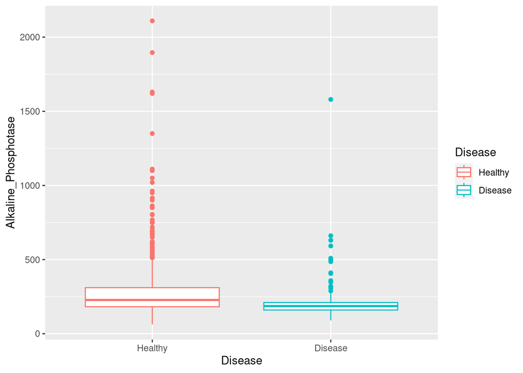

```r
df %>% ggplot(mapping = aes( x= Disease, y = Alkaline_Phosphotase, color = Disease)) +
  geom_boxplot()
```

3.Shortly reflect on the difference between bagging, random forests, and boosting.

All three methods are ensemble methods. Bagging deals with variation reduction in cassifiers. The principle is that by averaging the dependent variable outputs between multiple classifiers created by bootstraping sampling, the variation is reduced. Random forest (for trees only) employs a bagging method with the difference between a classical bagging algorithm and random-forest being that only a subset of the parameters are used every time a split is made. Finally boosting is similar to bagging only that each time a new classifier is created it re-updates its residuals based on the previous model error.

4. Apply bagging to the training data, to predict the outcome Disease, using the caret library.

```r
cvcontrol <- trainControl(method = "repeatedcv",
                          number = 10,
                          allowParallel = TRUE)
treeFit <- train(
  Disease ~ .,
  data = df,
  method = "treebag",
  trControl = cvcontrol,
  importance = TRUE
)
```

5. Interpret the variable importance measure using the varImp function on the trained model object.

```r
varImp(treeFit)
```

```
## treebag variable importance
##
##                            Overall
## Alkaline_Phosphotase        100.00
## Alamine_Aminotransferase     92.09
## Aspartate_Aminotransferase   87.90
## Total_Bilirubin              75.91
## Age                          73.54
## Direct_Bilirubin             62.75
## Total_Protiens               54.01
## Albumin                      50.80
## Ratio_Albumin_Globulin       40.98
## GenderFemale                  0.00
```

6. Create training set predictions based on the bagged model, and use the confusionMatrix() function from the caret package to assess it’s performance.`

```r
prediction = predict(treeFit, type = "raw")

matrix_tree = confusionMatrix(df$Disease,  prediction)
```

7. Now ask for the output of the bagged model. Explain why the under both approaches differ.

```r
treeFit
```

```
## Bagged CART
##
## 500 samples
##  10 predictor
##   2 classes: 'Healthy', 'Disease'
##
## No pre-processing
## Resampling: Cross-Validated (10 fold, repeated 1 times)
## Summary of sample sizes: 450, 450, 450, 450, 450, 450, ...
## Resampling results:
##
##   Accuracy  Kappa
##   0.678     0.1311671
```

8. Fit a random forest to the training data to predict the outcome Disease, using the caret library.

```r
rf_model = randomForest(Disease ~ ., data = df)
```

```r
rfst = train(Disease ~ ., method = "rf", data = df, trControl = cvcontrol,
  importance = TRUE)
```

9. Again, interpret the variable importance measure using the varImp function on the trained model object. Do you draw the same conclusions as under the bagged model?

```r
varImp(rfst)
```

```
## rf variable importance
##
##                            Importance
## Direct_Bilirubin               100.00
## Aspartate_Aminotransferase      87.54
## Alamine_Aminotransferase        85.35
## Age                             64.31
## Total_Bilirubin                 60.36
## Alkaline_Phosphotase            43.33
## Albumin                         38.06
## GenderFemale                    28.78
## Ratio_Albumin_Globulin          15.94
## Total_Protiens                   0.00
```

Here the bilirubin is the most important predictor compared to the alkaline phosphatase.

10. Output the model output from the random forest. Are we doing better than with the bagged model?

```r
rfst
```

```
## Random Forest
##
## 500 samples
##  10 predictor
##   2 classes: 'Healthy', 'Disease'
##
## No pre-processing
## Resampling: Cross-Validated (10 fold, repeated 1 times)
## Summary of sample sizes: 450, 450, 450, 450, 450, 450, ...
## Resampling results across tuning parameters:
##
##   mtry  Accuracy  Kappa
##    2    0.698     0.1286126
##    6    0.704     0.1775668
##   10    0.702     0.1654483
##
## Accuracy was used to select the optimal model using the largest value.
## The final value used for the model was mtry = 6.
```

11. Now, fit a boosting model using the caret library to predict disease status.` Hint: Use gradient boosting (the gbm method in caret).

```r
treeboost <- train(
  Disease ~ .,
  data = df,
  method = "gbm",
  trControl = cvcontrol,
  verbose = FALSE
)
```

12. Again, interpret the variable importance measure. You will have to call for summary() on the model object you just created. Compare the output to the previously obtained variable importance measures.

```r
varImp(treeboost)
```

```
## gbm variable importance
##
##                            Overall
## Alkaline_Phosphotase        100.00
## Age                          72.60
## Alamine_Aminotransferase     71.32
## Aspartate_Aminotransferase   69.96
## Direct_Bilirubin             50.99
## Total_Protiens               27.43
## Albumin                      19.70
## Ratio_Albumin_Globulin       16.53
## Total_Bilirubin              10.50
## GenderFemale                  0.00
```

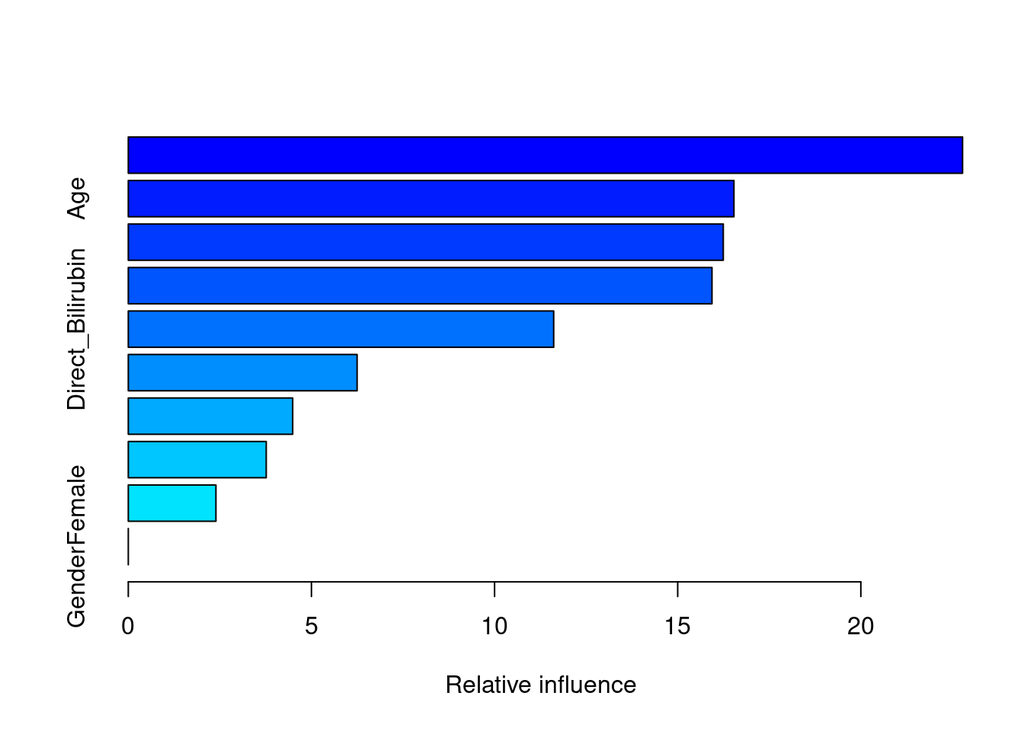

```
##                                                   var   rel.inf
## Alkaline_Phosphotase             Alkaline_Phosphotase 22.777111
## Age                                               Age 16.535626
## Alamine_Aminotransferase     Alamine_Aminotransferase 16.244192
## Aspartate_Aminotransferase Aspartate_Aminotransferase 15.935819
## Direct_Bilirubin                     Direct_Bilirubin 11.614064
## Total_Protiens                         Total_Protiens  6.246789
## Albumin                                       Albumin  4.488161
## Ratio_Albumin_Globulin         Ratio_Albumin_Globulin  3.765841
## Total_Bilirubin                       Total_Bilirubin  2.392397
## GenderFemale                             GenderFemale  0.000000
```

```r
summary(treeboost)
```

13. Output the model output from our gradient boosting procedure. Are we doing better than with the bagged and random forest model?

```r
treeboost
```

```
## Stochastic Gradient Boosting
##
## 500 samples
##  10 predictor
##   2 classes: 'Healthy', 'Disease'
##
## No pre-processing
## Resampling: Cross-Validated (10 fold, repeated 1 times)
## Summary of sample sizes: 450, 450, 450, 450, 450, 450, ...
## Resampling results across tuning parameters:
##
##   interaction.depth  n.trees  Accuracy  Kappa
##   1                   50      0.710     0.1260559
##   1                  100      0.718     0.1913173
##   1                  150      0.698     0.1502037
##   2                   50      0.696     0.1188807
##   2                  100      0.676     0.1009906
##   2                  150      0.690     0.1491582
##   3                   50      0.680     0.1072911
##   3                  100      0.700     0.1905759
##   3                  150      0.692     0.1775888
##
## Tuning parameter 'shrinkage' was held constant at a value of 0.1
##
## Tuning parameter 'n.minobsinnode' was held constant at a value of 10
## Accuracy was used to select the optimal model using the largest value.
## The final values used for the model were n.trees = 100, interaction.depth =
##  1, shrinkage = 0.1 and n.minobsinnode = 10.
```

The boosted method has a higher accuracy.

14. Download the file shap.R from this Github repository.

```r
library(devtools)
source_url("https://github.com/pablo14/shap-values/blob/master/shap.R?raw=TRUE")
```

```
## ℹ SHA-1 hash of file is "602645f005640081bb3b11b47eab27b730d74dc8"
```

15. Specify your model as follows, and use it to create predictions on the training data.

```r
train_x <- model.matrix(Disease ~ ., df)[,-1]
train_y <- as.numeric(df$Disease) - 1
xgboost_train <- xgboost(data = train_x,
                         label = train_y,
                         max.depth = 10,
                         eta = 1,
                         nthread = 4,
                         nrounds = 4,
                         objective = "binary:logistic",
                         verbose = 2)
pred <- tibble(Disease = predict(xgboost_train, newdata = train_x)) %>%
  mutate(Disease = factor(ifelse(Disease < 0.5, 1, 2),
                          labels = c("Healthy", "Disease")))

table(pred$Disease, df$Disease)
```

```
##
##           Healthy Disease
##   Healthy     357       6
##   Disease       3     134
```

16. First, calculate the SHAP rank scores for all variables in the data, and create a variable importance plot using these values. Interpret the plot.

```r
shap_results <- shap.score.rank(xgboost_train,
                                X_train = train_x,
                                shap_approx = F)
```

```
## make SHAP score by decreasing order
```

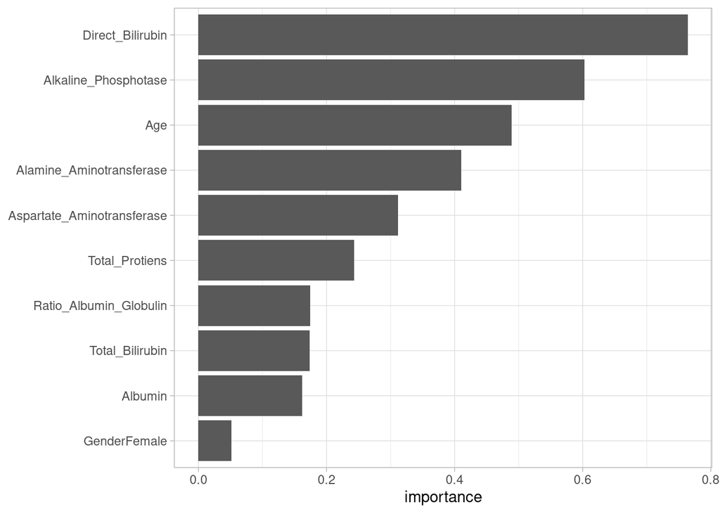

```r
var_importance(shap_results)
```

17. Plot the SHAP values for every individual for every feature and interpret them.

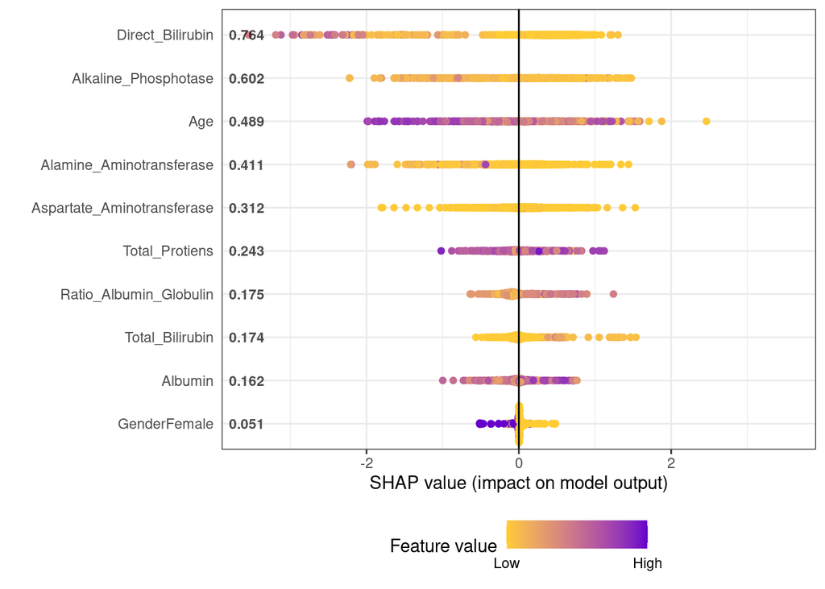

```r
shap_long <- shap.prep(shap = shap_results,
                       X_train = train_x)

plot.shap.summary(shap_long)
```

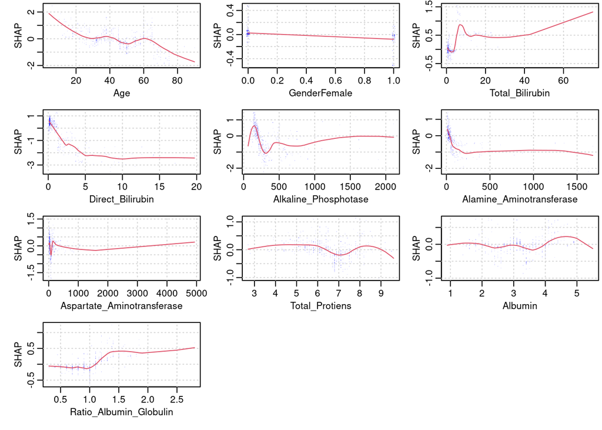

```r
xgb.plot.shap(train_x, features = colnames(train_x), model = xgboost_train, n_col = 3)
```

HIgh SHAP values show a higher probability of being diseased. For example high bilirubin values show a low chance of having the disease. This is the opposite for albumin values, as we can see the SHAP values go up with higher albumin values but only between 4-5. This could also be due to sampling variation.

18. Verify which of the models you created in this practical performs best on the test data.

```r
test <- readRDS("data/test_disease.RDS")

bag_test <- predict(treeFit, newdata = test)
rf_test  <- predict(rfst, newdata = test)
gbm_test <- predict(treeboost, newdata = test)
xgb_test <- predict(xgboost_train, newdata = model.matrix(Disease ~ ., test)[,-1]) %>%
  factor(x = ifelse(. < 0.5, 1, 2), levels = c(1,2), labels = c("Healthy", "Disease"))

list(bag_test,
     rf_test,
     gbm_test,
     xgb_test) %>%
  map(~ confusionMatrix(.x, test$Disease))
```

```
## [[1]]
## Confusion Matrix and Statistics
##
##           Reference
## Prediction Healthy Disease
##    Healthy      48      16
##    Disease       6       9
##
##                Accuracy : 0.7215
##                  95% CI : (0.6093, 0.8165)
##     No Information Rate : 0.6835
##     P-Value [Acc > NIR] : 0.27598
##
##                   Kappa : 0.2788
##
##  Mcnemar's Test P-Value : 0.05501
##
##             Sensitivity : 0.8889
##             Specificity : 0.3600
##          Pos Pred Value : 0.7500
##          Neg Pred Value : 0.6000
##              Prevalence : 0.6835
##          Detection Rate : 0.6076
##    Detection Prevalence : 0.8101
##       Balanced Accuracy : 0.6244
##
##        'Positive' Class : Healthy
##
##
## [[2]]
## Confusion Matrix and Statistics
##
##           Reference
## Prediction Healthy Disease
##    Healthy      53      18
##    Disease       1       7
##
##                Accuracy : 0.7595
##                  95% CI : (0.6502, 0.8486)
##     No Information Rate : 0.6835
```

[output cut: 60 more lines]

```
##                   Kappa : 0.2663
##
##  Mcnemar's Test P-Value : 0.5403
##
##             Sensitivity : 0.8148
##             Specificity : 0.4400
##          Pos Pred Value : 0.7586
##          Neg Pred Value : 0.5238
##              Prevalence : 0.6835
##          Detection Rate : 0.5570
##    Detection Prevalence : 0.7342
##       Balanced Accuracy : 0.6274
##
##        'Positive' Class : Healthy
##
```

Based on accuracy, the random forest model performs the best on the test data (0.75),